[◆ PeakAnnoAgent](https://github.com/helenhuangmath/PeakAnnoAgent)Report · 2026-10-11 18:06 · v1.0.0

# Accessible chromatin of chronically stimulated CD8 T cells: an Ep300/Runx3/Eomes enhancer landscape spanning progenitor and terminal exhaustion genes

**Peaks**example_tex_peaks_mm10.bed (351)

**Genome**mm10

**Assay**ATAC-seq

**Target**-

**Cell type**CD8 T cells

**Condition**chronic LCMV clone 13 infection, day 30

**Mode**agent (Claude (Claude Code session acting as the agent))

**Known biology provided**

Synthetic example. Peaks from chronically stimulated (exhausted-like) CD8 T cells. Exhaustion is driven by TOX and NR4A family factors downstream of persistent TCR/NFAT signalling, while TCF1 (Tcf7) marks the progenitor-exhausted subset. We want to know which pathways and transcription factors these peaks point to.

**Expected genes:** Tox, Pdcd1, Havcr2, Entpd1, Tcf7, Cd160

**Expected TFs:** Nfatc1, Nr4a1, Batf, Tcf7

## Summary

The 351 peaks are clean, narrow ATAC-like regions [E1]. 79% lie away from promoters, so this is mostly an enhancer landscape [E2]. Peak-linked genes are strongly enriched for T-cell differentiation and activation terms, in both promoter and distal peaks [E4]. All six expected exhaustion genes (Tox, Pdcd1, Havcr2, Entpd1, Tcf7, Cd160) carry peaks, often several each [E22].

In public ChIP-seq from immune cells, the peaks overlap most with Ep300, the cohesin subunit Smc1a, the CD8 T-cell transcription factors Bcl11b, Tbx21, Eomes and Runx3 (with its partner Cbfb), and the signalling factors Stat3 and NF-kB Rela [E16]. That pattern points to active T-cell enhancers. Batf is supported twice: its public ChIP-seq overlaps these peaks (rank 20) [E16] and its target genes overlap the peak-linked promoter genes (93% vs 56% background) [E8]. Tcf7 targets overlap less (89% vs 66%) [E7].

The expected NFAT and NR4A factors are **not** recovered by motifs or public co-binding [E22]. No motif passes FDR [E5, E6], so regulator calls here rest on public co-binding, not sequence.

**Important:** the user notes describe this as a synthetic example built around exhaustion genes. The pathway and signature enrichments are therefore partly circular and should not be read as discovery.

## Hypotheses and next experiments

### H1. The distal peaks are Ep300/cohesin-marked active enhancers bound by Runx3 and Eomes, which together maintain the accessible exhaustion landscape.

medium

Evidence: E2, E16

**Test:** Runx3 and Eomes CUT&RUN plus H3K27ac in chronic (cl13) vs acute (Arm) d30 CD8 T cells; then CRISPRi of the top shared distal peaks near Pdcd1 and Havcr2 with a PD-1/Tim-3 flow readout.

### H2. Batf is a direct regulator of the promoter-proximal part of this program even though its motif is not enriched in these sequences.

medium

Evidence: E8, E16, E5

**Test:** Batf CUT&RUN in Tex cells to test direct binding at the 67 overlapping promoters; ATAC-seq of Batf-deficient vs control P14 cells in clone 13 infection.

### H3. The peak set is a mixture of progenitor (TCF1+) and terminal exhausted chromatin rather than one state.

medium

Evidence: E4, E9, [PMID:32396847](https://pubmed.ncbi.nlm.nih.gov/32396847/)

**Test:** Sort Ly108+CX3CR1- progenitor and Tim-3+CX3CR1- terminal Tex cells and run ATAC separately; test whether progenitor-signature peaks (Tcf7, Sell, Ccr7) and terminal-signature peaks (Havcr2, Entpd1, Cd160) split by subset.

## Interpretation

### What the peaks are

QC found no duplicates, off-chromosome contigs or width outliers (median 350 bp) [E1]. With a -1000/+500 bp promoter window chosen for sharp ATAC peaks, 71 peaks are promoter-proximal, 277 distal and 3 more than 100 kb from any TSS [E2]. The median distance to the nearest TSS is about 13 kb [E2]. Most signal is therefore in introns and intergenic regions (25.6% and 36.8%) [E2]. That is typical of T-cell ATAC landscapes, where the state-specific changes are concentrated in enhancers. The exhaustion field describes Tex cells as having a distinct chromatin landscape from effector and memory cells [[PMID:31207603](https://pubmed.ncbi.nlm.nih.gov/31207603/)].

### Pathways and cell-state signatures

Promoter- and distal-linked genes both enrich for lymphocyte and T-cell differentiation (GO BP padj 1e-23 promoter, 3e-16 distal) and for Hallmark TNFA/NF-kB, IL2-STAT5 and allograft-rejection programs [E4].

All three user signatures are enriched: terminal exhaustion most strongly at promoters (padj 2e-28), with progenitor and effector-like signatures in both groups [E4]. So the accessible landscape covers genes of **both** the TCF1+ progenitor and the terminal exhausted states. The field describes these as distinct, developmentally linked subsets [[PMID:30778252](https://pubmed.ncbi.nlm.nih.gov/30778252/), [PMID:32396847](https://pubmed.ncbi.nlm.nih.gov/32396847/)].

The pathway networks collapse the redundant GO terms into five modules: lymphocyte differentiation, adaptive immune response, regulation of hemopoiesis, alpha-beta T-cell differentiation, and leukocyte cell-cell adhesion [E4]. In the gene-pathway network, Bcl6, Ccr7, Ifng, Lef1 and Tbx21 each sit in all five module-lead pathways [E4]. So the enrichment is driven by core T-cell fate regulators and effector genes, not by one narrow pathway.

The top individual ImmuneSigDB hits are generic activation contrasts from B cells, CD4 T cells and neutrophils [E4]. The network does separate out one CD8-specific module, however: four naive vs effector/memory CD8 signatures led by KAECH_NAIVE_VS_DAY15_EFF_CD8_TCELL_DN (best padj 1.4e-12) [E4]. That supports an effector/memory-differentiated CD8 identity, though not exhaustion specifically.

Among the user signatures, Cx3cr1 and Gzmb are shared by the terminal and effector-like signatures [E4]. That is consistent with the overlap between terminal-exhausted and effector-like states.

### Candidate regulators

- **Ep300 + cohesin (Smc1a)**: the strongest and most reproducible public overlap (Ep300 significant in 75/125 immune experiments) [E16]. This marks the peaks as active enhancers and is not tied to one cell state.
- **Bcl11b, Tbx21, Eomes, Runx3/Cbfb**: CD8 T-cell TFs whose public peaks overlap these regions in CD8/NK/T cells [E16]. They are the best-supported sequence-specific candidates.
- **Stat3 and Rela (NF-kB)**: signal-responsive factors, consistent with the Hallmark TNFA/NF-kB and IL2-STAT5 programs [E16, E4].
- **Batf**: no motif signal [E5, E6], but its public ChIP-seq co-binds these peaks (rank 20; 16/45 experiments) [E16, E22] and its target genes overlap the peak-linked promoter genes strongly (p = 4e-12) [E8].
- **Tcf7**: not among the top 25 co-binding factors [E22], with modest target overlap [E7]. Expected if only part of the population is progenitor-like.
- **Not supported**: Nfatc1 and Nr4a1 [E22]. TOX itself has no public immune ChIP-seq in the top hits, so TOX involvement cannot be tested with these data.

### Expression and public data

All 17 up- and 10 down-regulated genes in the user's table carry a linked peak. Peaks sit at genes going both up (Pdcd1, Tigit, Ctla4, Prdm1, Tox) and down (Bach2, Klf2, Tcf7) [E9]. With only 47 genes tested this is illustrative, not a genome-wide test [E9].

GEO has several directly comparable exhausted-CD8 chromatin datasets [E15]: 3D-genome studies of Tex cells with matched ATAC and CUT&RUN [GSE343748, GSE284090], a chromatin-hub study implicating Id proteins [GSE310322], and a Klf2 early-exhaustion ATAC set [GSE288039]. Any of these would be a natural overlap or replication set.

### Caveats

- Synthetic input: peaks were placed at preselected exhaustion and effector genes (user notes), so gene-set and signature enrichments are partly circular [E4].
- No motif passed FDR in all or distal peaks [E5, E6]; regulator calls rely on overlap with public ChIP-seq, which reflects co-occupancy, not causality [E16].
- ChIP-Atlas target lists cover more than half of all genes (13.8k Batf, 16.3k Tcf7 of 24.5k), so target-overlap tests have weak specificity [E7, E8].
- The RNA-seq table has only 47 genes, so the integration is illustrative [E9].
- Genes are linked to peaks by nearest TSS; distal peaks may regulate other genes.
- GREAT region-based enrichment was not run (rGREAT unavailable in this R install).

## Results

Each result has an id (E1, E2, …) that the narrative cites. Tables are linked relative to this report.

### Peak QC

E1

### Peak QC

ok

Why: Baseline QC before choosing annotation settings.

| n peaks | 351 |
| --- | --- |
| n clean peaks | 351 |
| width | min: 300, q25: 350, median: 350, q75: 350, max: 400 |
| n duplicated | 0 |
| n nonstandard chrom | 0 |
| n blacklisted | 0 |

#### top chromosomes

| Chr | N | Pct |
| --- | --- | --- |
| chr11 | 45 | 12.8 |
| chr1 | 40 | 11.4 |
| chr10 | 30 | 8.55 |
| chr6 | 28 | 7.98 |
| chr9 | 27 | 7.69 |

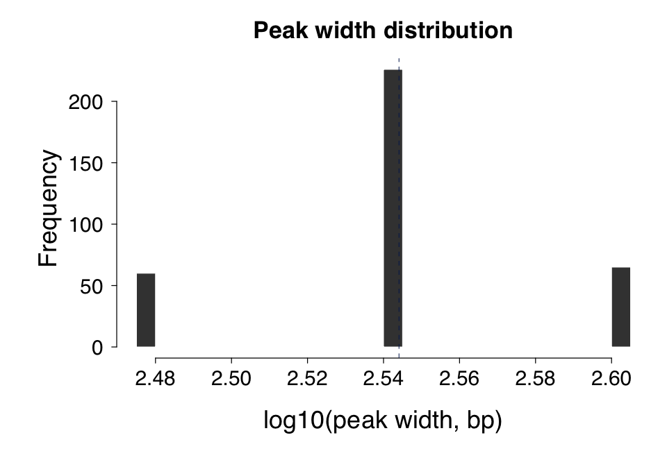

PDF (vector)

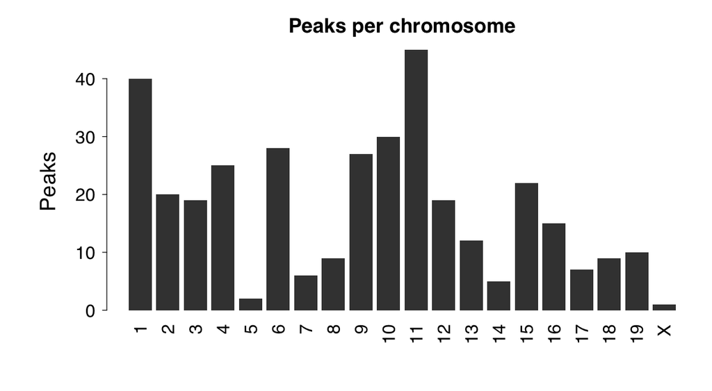

PDF (vector)

**Table: chromosomes - tex_qc_chromosomes.tsv**

| Chr | N | Pct |
| --- | --- | --- |
| chr11 | 45 | 12.82 |
| chr1 | 40 | 11.4 |
| chr10 | 30 | 8.55 |
| chr6 | 28 | 7.98 |
| chr9 | 27 | 7.69 |
| chr4 | 25 | 7.12 |
| chr15 | 22 | 6.27 |
| chr2 | 20 | 5.7 |
| chr3 | 19 | 5.41 |
| chr12 | 19 | 5.41 |

Showing 10 of 20 rows.

### Annotation

E2

### ChIPpeakAnno annotation

ok

Why: ATAC peaks are sharp; a -1000/+500 promoter window avoids calling nearby distal elements promoters.

| n peaks | 351 |
| --- | --- |
| region class counts | distal: 277, promoter: 71, distal_far: 3 |
| region distribution pct | Promoters: 25.1, immediateDownstream: 6.55, fiveUTRs: 0.28, threeUTRs: 0.57, Exons: 5.13, Introns: 25.6, Intergenic.Region: 36.8 |
| median abs distance to tss | 13247 |
| gene set sizes | promoter: 72, distal: 178, all: 192 |
| example promoter genes | Stat4, Ctla4, Ikzf2, Pdcd1, Il10, Rgs16, Sell, Cd244a, Myb, Taar9, Prdm1, Prf1, Egr2, Dusp6, Ifng, Havcr2, Tcf7, Ccl5, Ccl3, Ccl4, Mir8103, Tbx21, Ccr7, Stat3, Socs3, Id2, Fos, Batf, Irf4, Gzmk, Gzmb,… |
| promoter window | upstream: 1000, downstream: 500 |

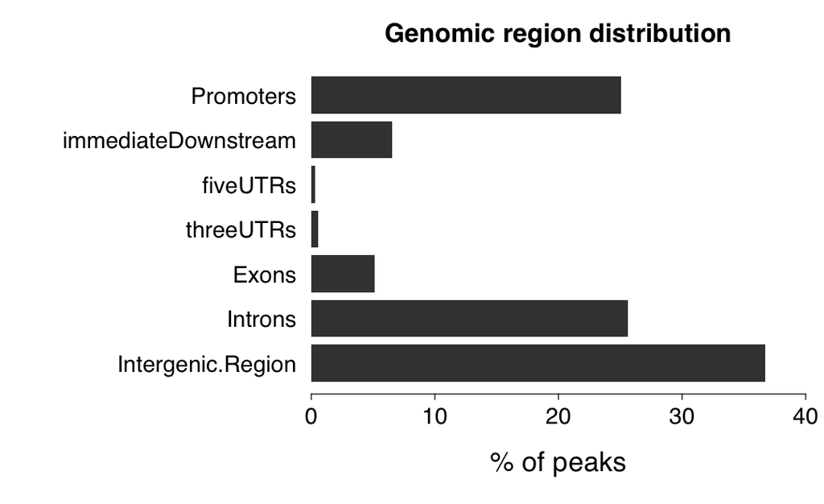

PDF (vector)

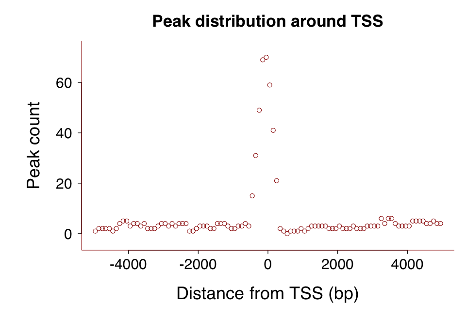

PDF (vector)

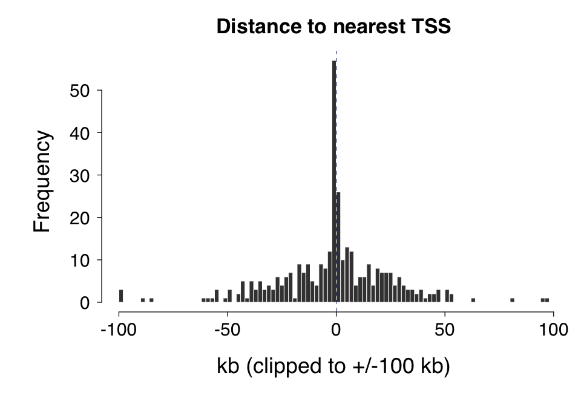

PDF (vector)

**Table: peak_genes - tex_chippeakanno_peak_genes.tsv**

| PeakID | Chr | Start | End | nearest_entrez | distance_to_tss | shortest_distance | inside_feature | nearest_symbol | promoter_symbols | region_class |
| --- | --- | --- | --- | --- | --- | --- | --- | --- | --- | --- |
| tex_peak_0001 | chr1 | 51937897 | 51938247 | 17912 | -22001 | 21826 | upstream | Myo1b |  | distal |
| tex_peak_0002 | chr1 | 51946851 | 51947201 | 17912 | -30955 | 30780 | upstream | Myo1b |  | distal |
| tex_peak_0003 | chr1 | 51970712 | 51971062 | 20849 | -16261 | 16086 | upstream | Stat4 |  | distal |
| tex_peak_0004 | chr1 | 51986720 | 51987120 | 20849 | -228 | 28 | upstream | Stat4 | Stat4 | promoter |
| tex_peak_0005 | chr1 | 52014147 | 52014497 | 20849 | 27174 | 26999 | inside | Stat4 |  | distal |
| tex_peak_0006 | chr1 | 60836977 | 60837327 | 12477 | -49848 | 49673 | upstream | Ctla4 |  | distal |
| tex_peak_0007 | chr1 | 60851151 | 60851501 | 12477 | -35674 | 35499 | upstream | Ctla4 |  | distal |
| tex_peak_0008 | chr1 | 60864420 | 60864770 | 12477 | -22405 | 22230 | upstream | Ctla4 |  | distal |
| tex_peak_0009 | chr1 | 60886890 | 60887290 | 12477 | 90 | 110 | overlapStart | Ctla4 | Ctla4 | promoter |
| tex_peak_0010 | chr1 | 60937771 | 60938121 | 54167 | -39981 | 39806 | upstream | Icos |  | distal |

Showing 10 of 351 rows.

**Table: region_distribution - tex_chippeakanno_region_distribution.tsv**

| Region | Pct |
| --- | --- |
| Promoters | 25.07 |
| immediateDownstream | 6.55 |
| fiveUTRs | 0.28 |
| threeUTRs | 0.57 |
| Exons | 5.13 |
| Introns | 25.64 |
| Intergenic.Region | 36.75 |

### Pathways

E4

### Pathway enrichment (go_bp, msigdb_H, msigdb_C7:IMMUNESIGDB, custom)

ok

#### Explore the pathways

Interactive view needs JavaScript.

Why: CD8 T-cell system: test immune-specific signatures (ImmuneSigDB) and the user exhaustion signatures, comparing promoter vs distal targets.

| methods | go_bp, msigdb_H, msigdb_C7:IMMUNESIGDB, custom |
| --- | --- |
| groups | promoter: 72, distal: 178 |
| universe size | 24511 |

#### n significant

| method | group | N |
| --- | --- | --- |
| go_bp | promoter | 811 |
| go_bp | distal | 389 |
| msigdb_H | promoter | 6 |
| msigdb_H | distal | 5 |
| msigdb_C7:IMMUNESIGDB | promoter | 1010 |
| msigdb_C7:IMMUNESIGDB | distal | 372 |
| custom | promoter | 3 |
| custom | distal | 3 |

#### top terms

| method | group | term | padj | count | genes |
| --- | --- | --- | --- | --- | --- |
| custom | distal | TEX_EFFECTOR_LIKE | 1.98e-17 | 8 | Prf1;Tbx21;Gzmb;Zeb2;S1pr1;Klrg1;Klf2;Cx3cr1 |
| custom | distal | TEX_PROGENITOR | 8.86e-17 | 8 | Sell;Myb;Tcf7;Ccr7;Lef1;Bach2;Id3;Cxcr5 |
| custom | distal | TEX_TERMINAL | 3.05e-13 | 7 | Pdcd1;Prdm1;Gzmb;Tigit;Entpd1;Tox;Cx3cr1 |
| custom | promoter | TEX_TERMINAL | 1.89e-28 | 11 | Pdcd1;Cd244a;Cd160;Tox;Lag3;Cx3cr1;Prdm1;Havcr2;Gzmb;Tigit;Entpd1 |
| custom | promoter | TEX_EFFECTOR_LIKE | 5.56e-21 | 8 | Zeb2;S1pr1;Klrg1;Klf2;Cx3cr1;Prf1;Tbx21;Gzmb |
| custom | promoter | TEX_PROGENITOR | 3.33e-20 | 8 | Sell;Lef1;Bach2;Id3;Cxcr5;Myb;Tcf7;Ccr7 |
| go_bp | distal | lymphocyte differentiation | 2.92e-16 | 30 | Stat4;Ctla4;Il10;Myb;Prdm1;Ifng;Tcf7;Tbx21;Ccr7;Smarce1;Stat5a;Stat3 |
| go_bp | distal | T cell differentiation | 4.16e-15 | 25 | Stat4;Ctla4;Myb;Prdm1;Ifng;Tcf7;Tbx21;Ccr7;Smarce1;Stat5a;Stat3;Irf4 |
| go_bp | distal | alpha-beta T cell differentiation | 1.55e-13 | 17 | Stat4;Myb;Prdm1;Ifng;Tcf7;Tbx21;Ccr7;Stat3;Irf4;Ptger4;Socs1;Bcl6 |
| go_bp | distal | regulation of lymphocyte differentiation | 1.72e-13 | 20 | Ctla4;Il10;Prdm1;Ifng;Tcf7;Tbx21;Ccr7;Smarce1;Stat5a;Id2;Il7r;Socs1 |
| go_bp | distal | regulation of leukocyte differentiation | 1.05e-12 | 23 | Ctla4;Il10;Prdm1;Ifng;Tcf7;Ccl9;Ccl3;Tbx21;Ccr7;Smarce1;Stat5a;Id2 |
| go_bp | promoter | lymphocyte differentiation | 1.15e-23 | 27 | Stat4;Ctla4;Il10;Il2ra;Il21;Lef1;Tox;Runx3;Cd8a;Lag3;Eomes;Myb |

Showing 12 of 36 rows.

#### go bp

| module | lead_term | n_terms | best_padj | other_terms |
| --- | --- | --- | --- | --- |
| 1 | lymphocyte differentiation | 6 | 1.15e-23 | T cell differentiation; alpha-beta T cell activation; alpha-beta T cell differentiation |
| 2 | adaptive immune response | 6 | 2.30e-22 | leukocyte activation involved in immune response; lymphocyte activation involved in immune response; cell activation involved in immune response |
| 3 | regulation of hemopoiesis | 7 | 1.75e-19 | regulation of leukocyte differentiation; regulation of lymphocyte differentiation; positive regulation of leukocyte differentiation |
| 4 | alpha-beta T cell differentiation involved in immune response | 5 | 3.02e-17 | alpha-beta T cell activation involved in immune response; T cell differentiation involved in immune response; CD4-positive, alpha-beta T cell differentiation involved in immune response |
| 5 | leukocyte cell-cell adhesion | 6 | 5.34e-17 | regulation of T cell activation; positive regulation of cell activation; regulation of leukocyte cell-cell adhesion |

#### msigdb H

| module | lead_term | n_terms | best_padj | other_terms |
| --- | --- | --- | --- | --- |
| 1 | HALLMARK_TNFA_SIGNALING_VIA_NFKB | 1 | 2.32e-10 |  |
| 2 | HALLMARK_ALLOGRAFT_REJECTION | 3 | 1.45e-07 | HALLMARK_INTERFERON_GAMMA_RESPONSE; HALLMARK_IL6_JAK_STAT3_SIGNALING |
| 3 | HALLMARK_IL2_STAT5_SIGNALING | 1 | 7.93e-06 |  |
| 4 | HALLMARK_INFLAMMATORY_RESPONSE | 1 | 0.00169 |  |

#### msigdb C7:IMMUNESIGDB

| module | lead_term | n_terms | best_padj | other_terms |
| --- | --- | --- | --- | --- |
| 1 | GSE7218_UNSTIM_VS_ANTIGEN_STIM_THROUGH_IGG_BCELL_DN | 7 | 2.56e-17 | GSE7219_UNSTIM_VS_LPS_AND_ANTI_CD40_STIM_NIK_NFKB2_KO_DC_DN; GSE7219_WT_VS_NIK_NFKB2_KO_DC_UP; GSE21670_UNTREATED_VS_TGFB_TREATED_STAT3_KO_CD4_TCELL_DN |
| 2 | GSE45739_UNSTIM_VS_ACD3_ACD28_STIM_WT_CD4_TCELL_DN | 5 | 1.00e-16 | GSE45739_UNSTIM_VS_ACD3_ACD28_STIM_NRAS_KO_CD4_TCELL_DN; GSE3039_NKT_CELL_VS_ALPHAALPHA_CD8_TCELL_DN; GSE22886_NAIVE_CD8_TCELL_VS_MONOCYTE_UP |
| 3 | GSE3565_CTRL_VS_LPS_INJECTED_SPLENOCYTES_UP | 6 | 2.43e-14 | GSE3565_CTRL_VS_LPS_INJECTED_DUSP1_KO_SPLENOCYTES_UP; GSE15330_LYMPHOID_MULTIPOTENT_VS_MEGAKARYOCYTE_ERYTHROID_PROGENITOR_IKAROS_KO_DN; GSE3565_DUSP1_VS_WT_SPLENOCYTES_UP |
| 4 | KAECH_NAIVE_VS_DAY15_EFF_CD8_TCELL_DN | 4 | 1.35e-12 | KAECH_NAIVE_VS_MEMORY_CD8_TCELL_DN; GOLDRATH_NAIVE_VS_MEMORY_CD8_TCELL_DN; GSE9650_NAIVE_VS_EFF_CD8_TCELL_DN |
| 5 | GSE19923_WT_VS_HEB_AND_E2A_KO_DP_THYMOCYTE_DN | 6 | 2.17e-11 | GSE9988_LOW_LPS_VS_CTRL_TREATED_MONOCYTE_UP; GSE36891_POLYIC_TLR3_VS_PAM_TLR2_STIM_PERITONEAL_MACROPHAGE_UP; GSE23925_LIGHT_ZONE_VS_NAIVE_BCELL_UP |
| 6 | GSE2405_0H_VS_12H_A_PHAGOCYTOPHILUM_STIM_NEUTROPHIL_UP | 1 | 2.29e-11 |  |
| 7 | GSE7219_UNSTIM_VS_LPS_AND_ANTI_CD40_STIM_DC_UP | 1 | 8.29e-10 |  |

#### custom

| module | lead_term | n_terms | best_padj | other_terms |
| --- | --- | --- | --- | --- |
| 1 | TEX_TERMINAL | 1 | 1.89e-28 |  |
| 2 | TEX_EFFECTOR_LIKE | 1 | 5.56e-21 |  |
| 3 | TEX_PROGENITOR | 1 | 3.33e-20 |  |

#### go bp

| gene | n_pathways |
| --- | --- |
| Bcl6 | 5 |
| Ccr7 | 5 |
| Ifng | 5 |
| Lef1 | 5 |
| Tbx21 | 5 |
| Ctla4 | 4 |
| Il21 | 4 |
| Il7r | 4 |
| Lag3 | 4 |
| Stat3 | 4 |
| Batf | 3 |
| Eomes | 3 |

Showing 12 of 15 rows.

#### msigdb H

| gene | n_pathways |
| --- | --- |
| Ccl5 | 4 |
| Il2rb | 4 |
| Cd69 | 3 |
| Il10 | 3 |
| Il15ra | 3 |
| Irf4 | 3 |
| Socs1 | 3 |
| Ccl4 | 2 |
| Il2ra | 2 |
| Il7r | 2 |
| Ptger4 | 2 |
| Rgs16 | 2 |

Showing 12 of 15 rows.

#### msigdb C7:IMMUNESIGDB

| gene | n_pathways |
| --- | --- |
| Gzmk | 4 |
| Prf1 | 4 |
| Ccl4 | 3 |
| Ccl5 | 3 |
| Id2 | 3 |
| Ifng | 3 |
| Klrg1 | 3 |
| Prdm1 | 3 |
| Tbx21 | 3 |
| Cd160 | 2 |
| Cish | 2 |
| Ctla4 | 2 |

Showing 12 of 15 rows.

#### custom

| gene | n_pathways |
| --- | --- |
| Cx3cr1 | 2 |
| Gzmb | 2 |

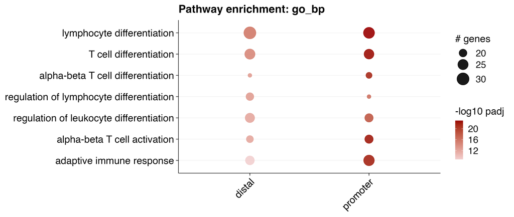

PDF (vector)

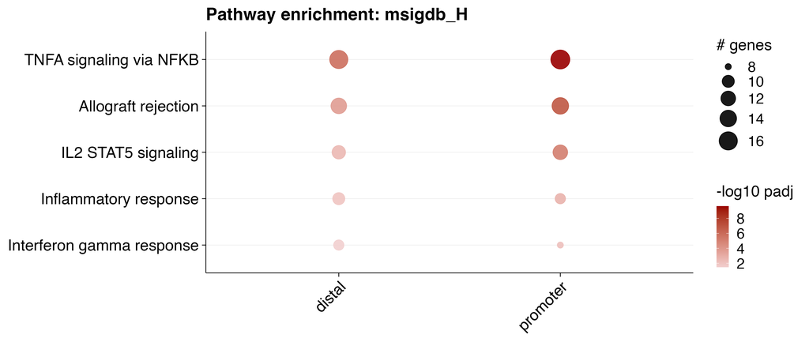

PDF (vector)

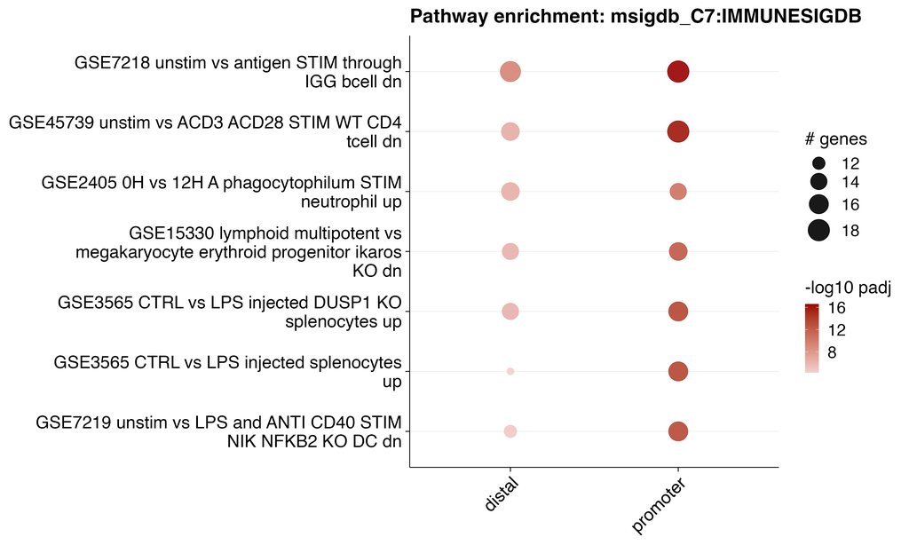

PDF (vector)

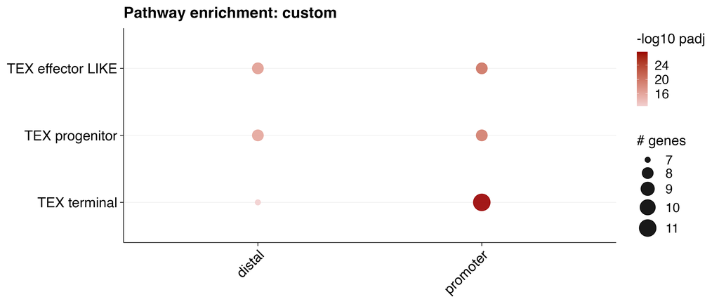

PDF (vector)

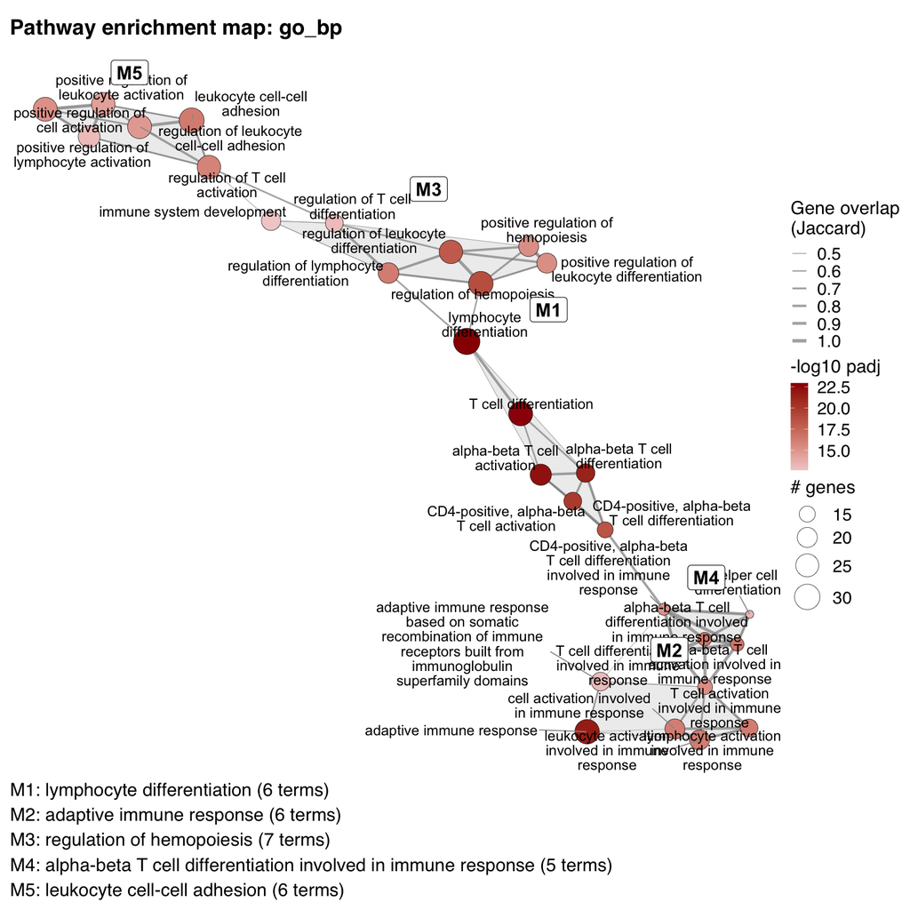

PDF (vector)

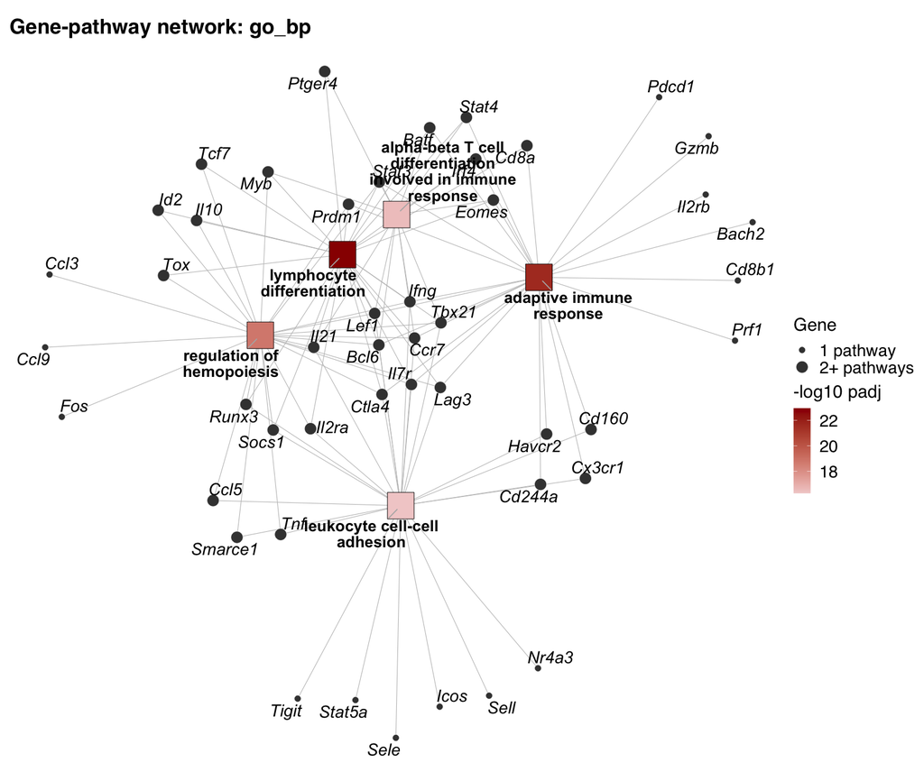

PDF (vector)

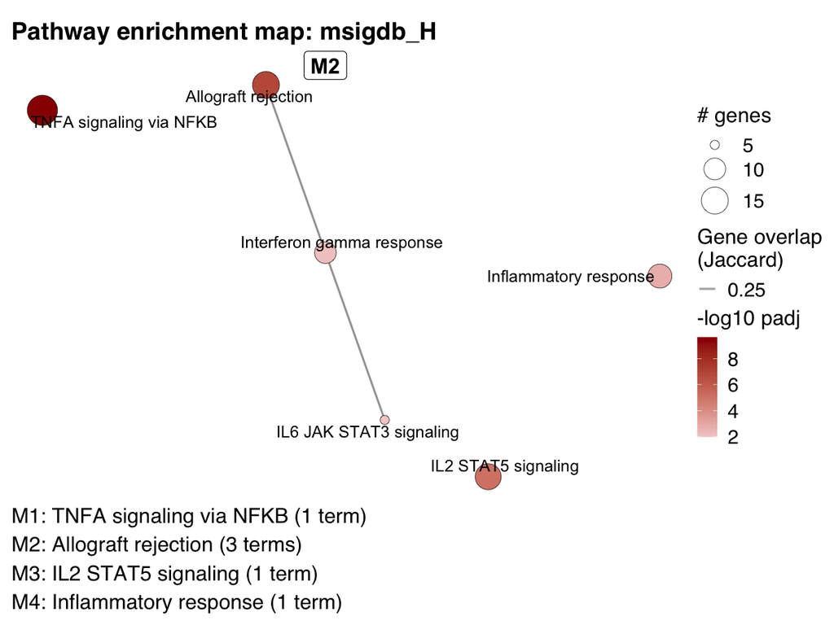

PDF (vector)

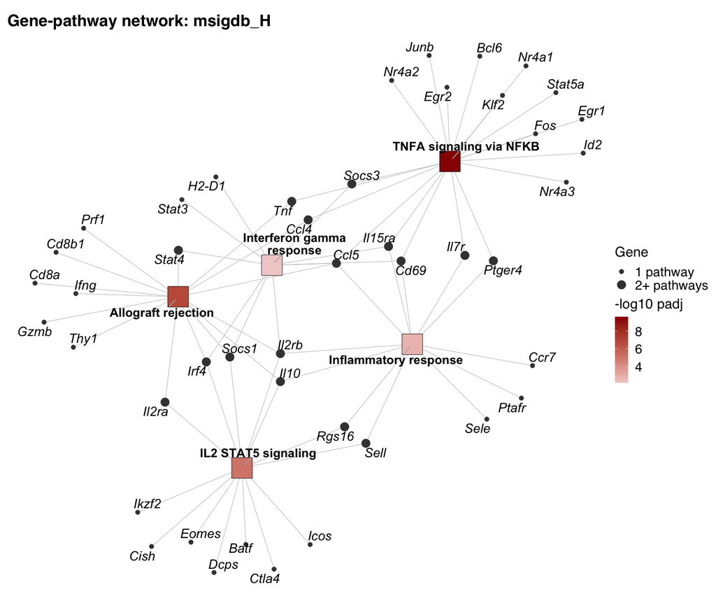

PDF (vector)

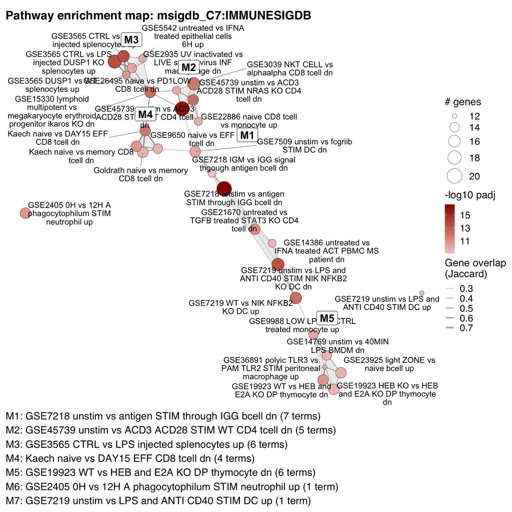

PDF (vector)

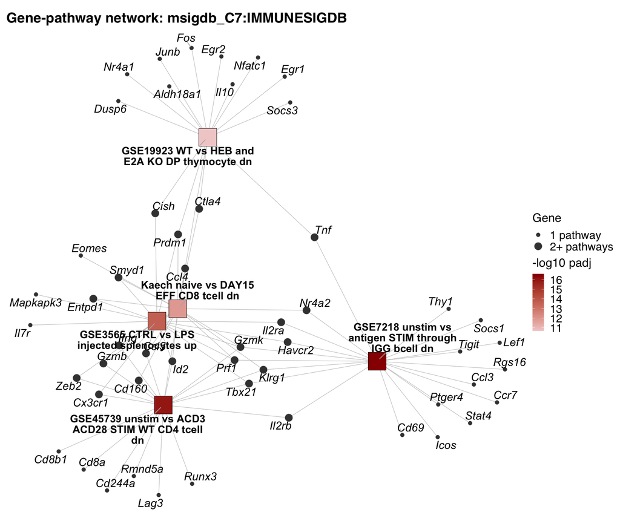

PDF (vector)

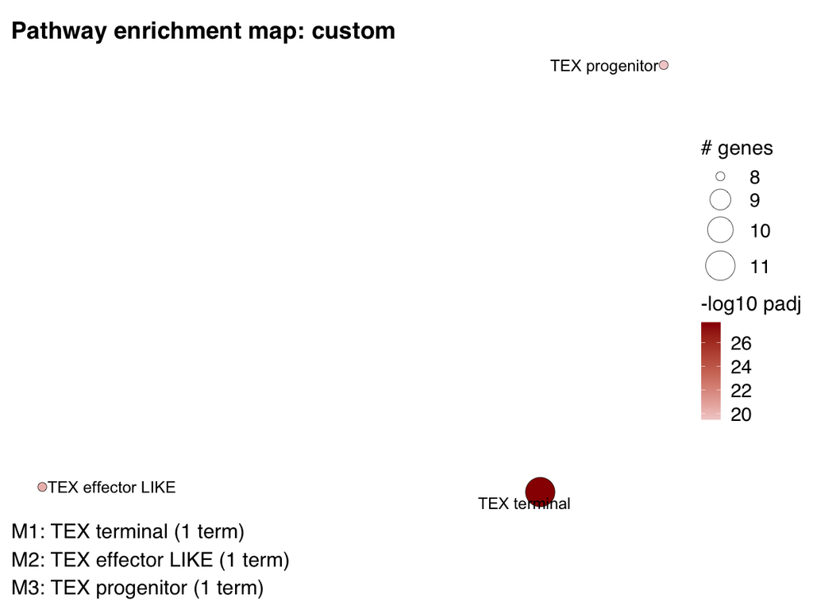

PDF (vector)

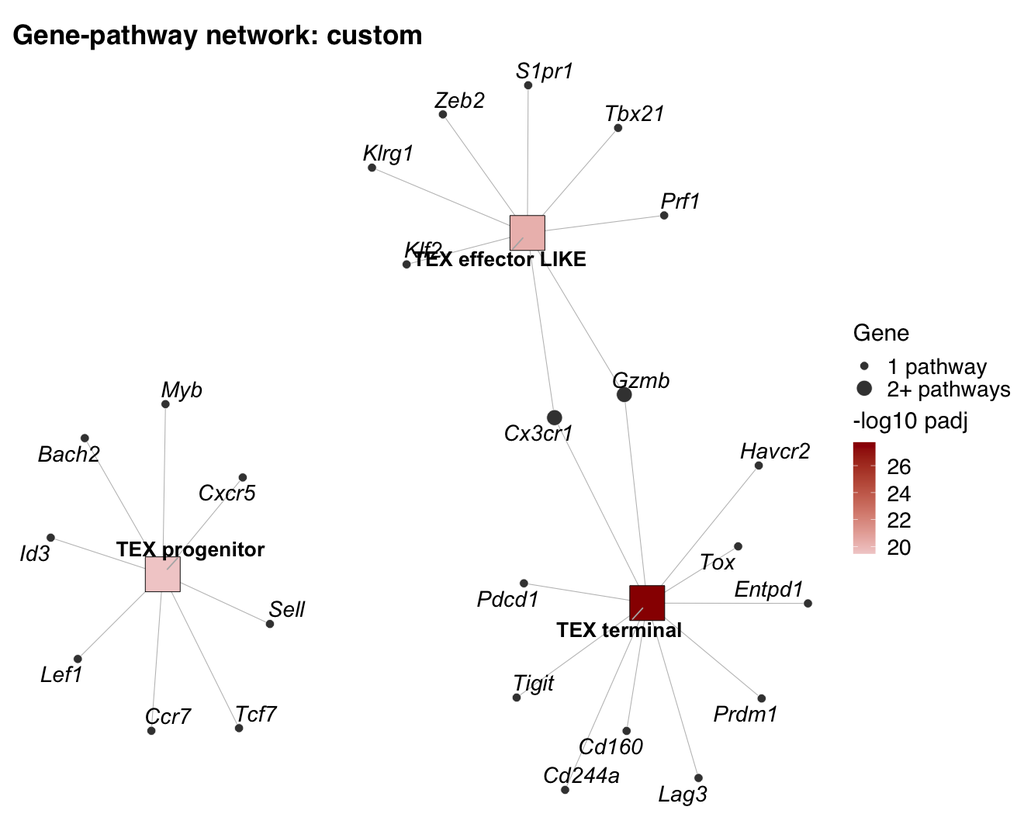

PDF (vector)

**Table: enrichment - tex_enrich1_enrichment.tsv**

| method | group | term_id | term | gene_ratio | bg_ratio | pvalue | padj | count | genes |
| --- | --- | --- | --- | --- | --- | --- | --- | --- | --- |
| go_bp | promoter | GO:0030098 | lymphocyte differentiation | 27/71 | 474/22167 | 4.82264930917463e-27 | 1.15068412516907e-23 | 27 | Stat4;Ctla4;Il10;Il2ra;Il21;Lef1;Tox;Runx3;Cd8a;Lag3;Eomes;Myb;Prdm1;Ifng;Tcf7;Tbx21;Ccr7;Stat3;Id2;Batf;Irf4;Ptger4;Il7r;Socs1;Bcl6;Egr1;Nfatc1 |
| go_bp | promoter | GO:0030217 | T cell differentiation | 24/71 | 334/22167 | 2.28410107385192e-26 | 2.72493258110533e-23 | 24 | Stat4;Ctla4;Il2ra;Il21;Lef1;Tox;Runx3;Cd8a;Lag3;Eomes;Myb;Prdm1;Ifng;Tcf7;Tbx21;Ccr7;Stat3;Batf;Irf4;Ptger4;Il7r;Socs1;Bcl6;Egr1 |
| go_bp | promoter | GO:0046631 | alpha-beta T cell activation | 21/71 | 218/22167 | 9.39056055931695e-26 | 7.46862583151008e-23 | 21 | Stat4;Cd244a;Il2ra;Il21;Cd160;Lef1;Tox;Runx3;Eomes;Myb;Prdm1;Ifng;Tcf7;Tbx21;Ccr7;Stat3;Batf;Irf4;Ptger4;Socs1;Bcl6 |
| go_bp | promoter | GO:0002250 | adaptive immune response | 26/71 | 493/22167 | 3.85228680627999e-25 | 2.29788907994601e-22 | 26 | Stat4;Ctla4;Pdcd1;Cd244a;Cd160;Lef1;Bach2;Cd8b1;Cd8a;Lag3;Eomes;Cx3cr1;Prdm1;Prf1;Ifng;Havcr2;Tbx21;Ccr7;Stat3;Batf;Irf4;Gzmb;Il7r;Il2rb;Bcl6;Tnf |
| go_bp | promoter | GO:0046632 | alpha-beta T cell differentiation | 18/71 | 135/22167 | 9.73087710418402e-25 | 4.64357455411662e-22 | 18 | Stat4;Il21;Lef1;Tox;Runx3;Eomes;Myb;Prdm1;Ifng;Tcf7;Tbx21;Ccr7;Stat3;Batf;Irf4;Ptger4;Socs1;Bcl6 |
| go_bp | promoter | GO:0035710 | CD4-positive, alpha-beta T cell activation | 17/71 | 130/22167 | 3.08836863860053e-23 | 1.22814126195015e-20 | 17 | Stat4;Il2ra;Il21;Cd160;Lef1;Tox;Runx3;Myb;Ifng;Tbx21;Ccr7;Stat3;Batf;Irf4;Ptger4;Socs1;Bcl6 |
| go_bp | promoter | GO:1903706 | regulation of hemopoiesis | 23/71 | 443/22167 | 5.12175158657633e-22 | 1.74578561222444e-19 | 23 | Ctla4;Il10;Il2ra;Il21;Lef1;Tox;Runx3;Lag3;Myb;Prdm1;Ifng;Tcf7;Ccl5;Ccl3;Tbx21;Ccr7;Stat3;Id2;Fos;Il7r;Socs1;Bcl6;Tnf |
| go_bp | promoter | GO:0043367 | CD4-positive, alpha-beta T cell differentiation | 15/71 | 98/22167 | 1.17588585742042e-21 | 3.50707956975642e-19 | 15 | Stat4;Il21;Lef1;Tox;Runx3;Myb;Ifng;Tbx21;Ccr7;Stat3;Batf;Irf4;Ptger4;Socs1;Bcl6 |
| go_bp | promoter | GO:1902105 | regulation of leukocyte differentiation | 21/71 | 357/22167 | 3.24466171318495e-21 | 8.60195871962144e-19 | 21 | Ctla4;Il10;Il2ra;Il21;Lef1;Tox;Runx3;Lag3;Prdm1;Ifng;Tcf7;Ccl5;Ccl3;Tbx21;Ccr7;Id2;Fos;Il7r;Socs1;Bcl6;Tnf |
| go_bp | promoter | GO:0002293 | alpha-beta T cell differentiation involved in immune response | 13/71 | 75/22167 | 1.26668251599082e-19 | 3.02230448315409e-17 | 13 | Stat4;Il21;Lef1;Eomes;Myb;Ifng;Tbx21;Ccr7;Stat3;Batf;Irf4;Ptger4;Bcl6 |

Showing 10 of 2599 rows.